# Time Series Analysis - LBMA Gold Price

I-Lun Tu

# Abstract

In this report, there are two goals: (1) Provide an explanation on how the gold fixing prices vary. (2) Provide predictions/ forecasts on the future gold fixing prices. For the first goal, we have successfully built a regression with auto-correlated error model that can explain log transformed gold fixing price using log transformed volatility value and its quadratic form and with residuals structure being SARIMA(0,1,0)(0,0,1)(6). For the second goal, we build a SARIMA(1,1,0)(1,0,0)(6) model and provide five steps ahead predictions and standard errors.

# Introduction

Gold price itself is a good leading indication of how the current state of economy is in and where the economy will head toward. The ability to explain and predict gold price can aid in the planning of fiscal and monetary policies for government as well as investment planning for private sectors.

We can often observe positive relationships between the price of gold and the rate of inflation. That is, when rate of inflation is increasing, gold price tends to rise. This result stems from the fact that gold is the most basic and natural choice for store of value. Currently, due to the unprecedented economic hardship brought by Covid-19, there have been many quantitative easing policies in place, and in turn, inflation rate has been increasing for a prolonged period. As a result, gold prices have been rising but with a volatile path. Many questions has been asked whether inflation rate is running out of control? Should quantitative easing continue? Therefore, in this report we try to explain and predict gold fixing price with the intention that this may be useful to explain how the inflation rate will vary.

The price of gold we used in this analysis is “The London Bullion Market Association (LBMA) Gold Price”. In essence, this is the bench mark of all the gold prices around the world. LBMA is the largest OTC market and is participated by dominant banks around the world. Gold prices decided here will have ripple effects on various other lesser gold markets. The price is recorded in U.S. dollar per troy ounce. The frequency of this data is twice per day (10:30am & 3:30pm London time). We use the daily 10:30 am data and the this series has over 1,000 data points. This data set is recorded by ICE Benchmark Administration and is provided by U.S Federal reserve bank at St. Louis.

The predictor variable we choose is gold ETF volatility index. We understand that gold price itself is influenced by many competing factors ranging from tangible economic activities such as the making of ornamental objects and industrial component; intangible activities such as hedging against inflation. The attempt to incorporate as many predictors as possible will often result in multi-collinearity issues. Gold ETF volatility index consists of a portfolio of stocks designed to closely track the price performance and yield of gold. Therefore, this can be thought of as a pool of information directly related to gold price. In a sense, we can use this predictor to capture many aspects of the variation of gold price without running the risks of multi-collinearity issues as well as building too complicated a model.

# Analysis

## Generalized Least Square

```r
# data preparation
Gold<- read.table("C:\\Users\\absur\\Desktop\\Pis\\[2] UIUC\\[1] Courses\\Statistics 429\\Final Project\\GOLDAMGBD228NLBM.csv"
                   , header = T, sep = ",")
Volatility<- read.table("C:\\Users\\absur\\Desktop\\Pis\\[2] UIUC\\[1] Courses\\Statistics 429\\Final Project\\GVZCLS.csv"
                        , header = T, sep = ",")
data1<- left_join(Gold,Volatility,by = "DATE")
data1<- data1 %>% rename(gold=GOLDAMGBD228NLBM,volatility=GVZCLS)
data1<- data1 %>% filter(gold != ".", volatility!=".")
data1<- as_tibble(data1)
data1<- data1 %>% mutate_at(c("gold","volatility"),as.numeric)
data1<- data1 %>% mutate(gold_log=log(gold),vol_log=log(volatility))
data1<- data1 %>% separate(DATE, into=c("Year","Month","Date"),sep="-")
counting<- data1 %>% group_by(Year) %>% summarize(n=n())
time.2016<- seq(from=2016, to=2017,by=1/246)[222:246]
time.2017<- seq(from=2017,to=2018,by=1/246)[1:246]
time.2018<- seq(from=2018,to=2019,by=1/247)[1:247]
time.2019<- seq(from=2019,to=2020,by=1/247)[1:247]
time.2020<- seq(from=2020,to=2021,by=1/248)[1:248]
time.2021<- seq(from=2021,to=2022,by=1/246)[1:223]
time.stamp<- c(time.2016,time.2017,time.2018,time.2019,time.2020,time.2021)
data1<- data1 %>% mutate(time=time.stamp)
```

### 1. Preliminary data analysis

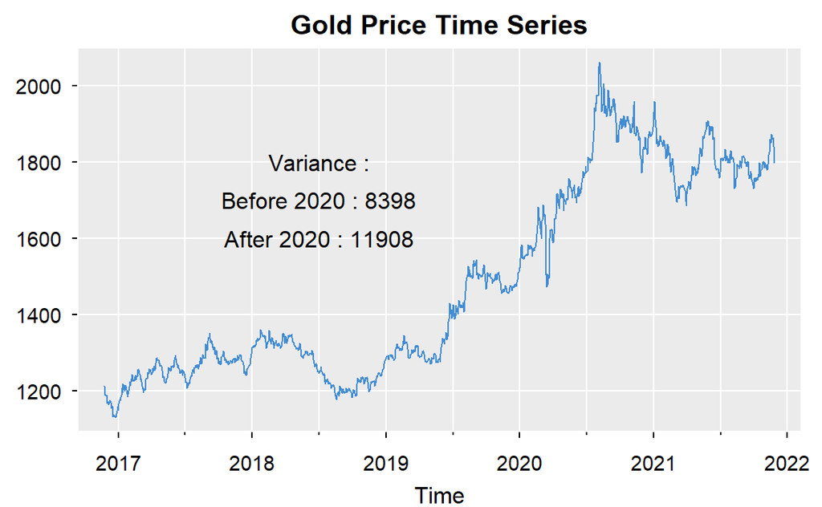

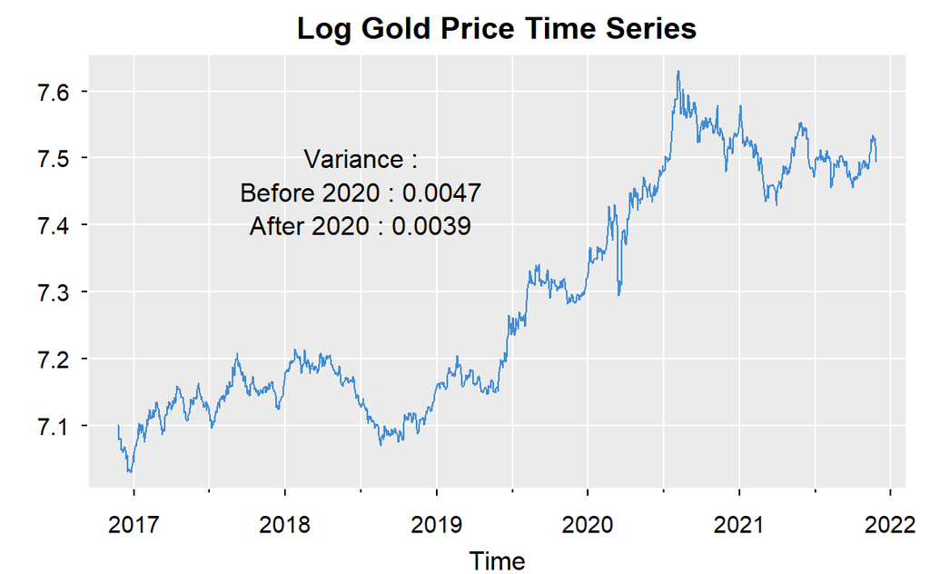

```r
par(mfrow=c(1,1))
tsplot(data1$time,data1$gold,type = "l",xlab = "Time",ylab = "",col=astsa.col(4, .8),gg=TRUE,lwd=1,main = "Gold Price Time Series")

after.2020<- data1 %>% slice(766:dim(data1)[1])
before.2020<- data1 %>% slice(1:765)

text(2018.5,1800, paste("Variance :" ))
text(2018.5,1700,paste("Before 2020 :",round(var(before.2020$gold))))
text(2018.5,1600,paste("After 2020 :",round(var(after.2020$gold))))


tsplot(data1$time,data1$gold_log,type = "l",xlab = "Time",ylab = "",col=astsa.col(4, .8),gg=TRUE,lwd=1,main = "Log Gold Price Time Series")

text(2018.5,7.5, paste("Variance :" ))
text(2018.5,7.45, paste("Before 2020 :",round(var(before.2020$gold_log),4)))
text(2018.5,7.40, paste("After 2020 :",round(var(after.2020$gold_log),4)))

par(mfrow=c(1,1))
```

(2). From below left, We can see that this series is highly auto correlated. ACF decays really slowly. Overall, this suggest that this time series data is not stationary.

(3). From below right, We find out that log-transformed volatility index has higher linear relationship(0.71) than its original form(0.64). This suggests that it will provide more explanatory power in a regression model. Thus, we proceed to use log transformed volatility index as predictor variable. Also, as this is an economic data, this transformation makes sense in this context.

```r
acf1(data1$gold_log,main = "Dependence of Log Gold Price",gg=TRUE,lwd=2)
```

```
##  [1] 1.00 0.99 0.99 0.99 0.99 0.98 0.98 0.98 0.98 0.97 0.97 0.97 0.97 0.96 0.96
## [16] 0.96 0.96 0.95 0.95 0.95 0.95 0.94 0.94 0.94 0.94 0.93 0.93 0.93 0.93 0.93
## [31] 0.92 0.92 0.92 0.92 0.91 0.91 0.91 0.91 0.91 0.90 0.90 0.90 0.90 0.89 0.89
## [46] 0.89
```

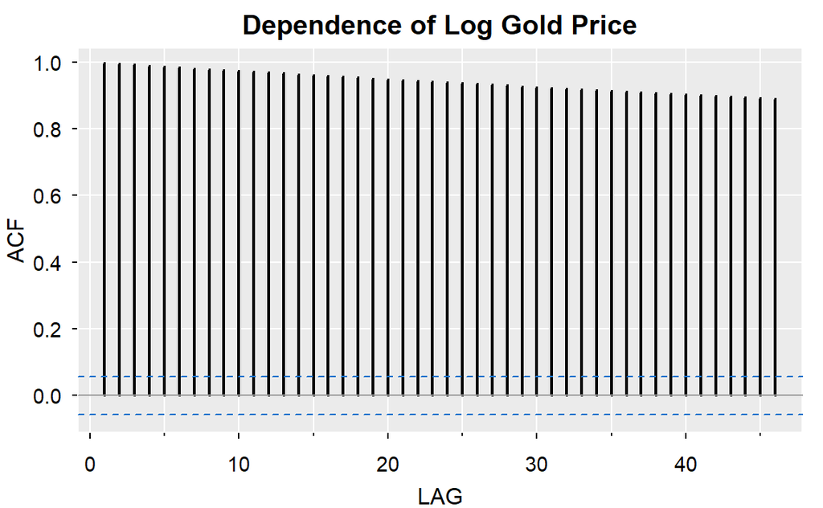

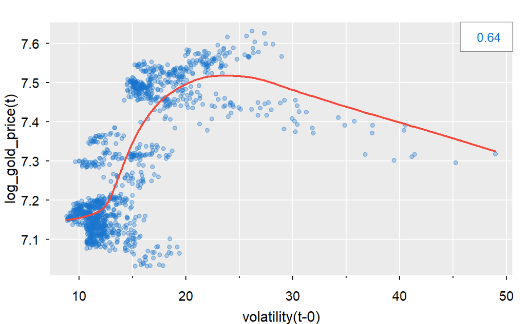

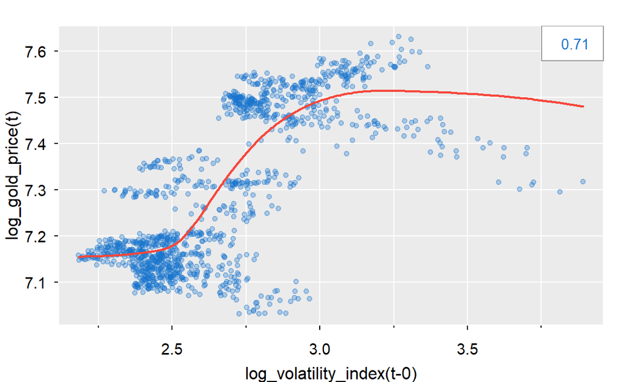

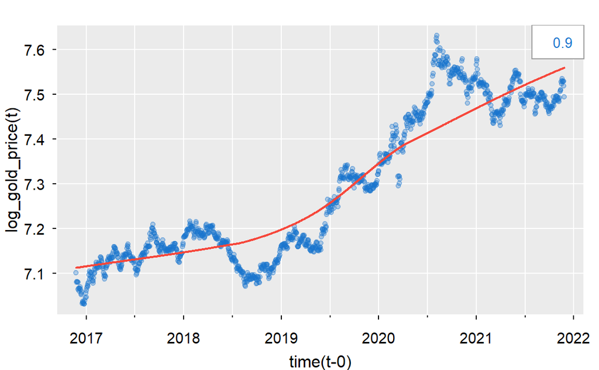

```r
volatility<- data1$volatility
log_gold_price<- data1$gold_log
log_volatility_index<- data1$vol_log
time<- data1$time

lag2.plot(volatility,log_gold_price,max.lag = 0,lwl = 2,gg=TRUE,col=astsa.col(4, .3), pch=20, cex=1)
lag2.plot(log_volatility_index,log_gold_price,max.lag = 0,lwl = 2,gg=TRUE,col=astsa.col(4, .3), pch=20, cex=1)
lag2.plot(time,log_gold_price,max.lag = 0,lwl = 2,gg=TRUE,col=astsa.col(4, .3), pch=20, cex=1)
```

### 2. Regression Model

(1). Regression Model: log(Gold)= B0 + B1 * log(volatility) + B2* log(volatility)^2 + B3*time. The estimated coefficients are really significant and the fitted model is not bad at explaining variation within the data.

```r
fit1<- lm(gold_log~vol_log+I(vol_log^2)+time,data = data1)
fit1 %>% summary() %>% coefficients()
```

```
##                   Estimate  Std. Error   t value     Pr(>|t|)
## (Intercept)  -160.69442685 2.486088499 -64.63745 0.000000e+00
## vol_log         1.12912794 0.075989921  14.85892 4.607224e-46
## I(vol_log^2)   -0.16712997 0.013461680 -12.41524 1.968359e-33
## time            0.08228955 0.001242939  66.20561 0.000000e+00
```

```r
results<- fit1 %>% summary()
paste("Adjusted R Square",":",round(results$adj.r.squared,4))
```

```
## [1] "Adjusted R Square : 0.9005"
```

(2). We check the residuals to see whether they satisfied the normal iid assumptions. From the below time series plot, we observe that that they are not white noise and there are clear cyclical behaviors. From the ACF, it is auto-correlated for many lags. Therefore, we should apply regression with auto-correlated errors.

```
##  [1] 0.96 0.94 0.92 0.90 0.88 0.85 0.84 0.83 0.82 0.81 0.79 0.78 0.77 0.76 0.75
## [16] 0.74 0.72 0.71 0.70 0.69 0.68 0.67 0.65 0.64 0.63 0.62 0.61 0.60 0.60 0.58
## [31] 0.57 0.56 0.55 0.54 0.53 0.52 0.51 0.50 0.48 0.47 0.46 0.45 0.44 0.43 0.42
## [46] 0.42
```

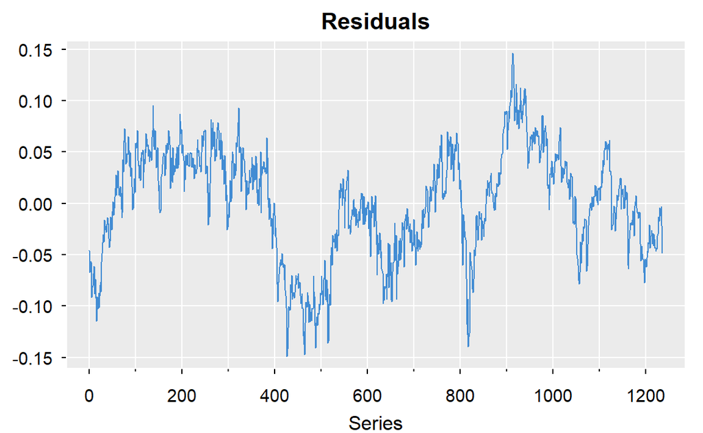

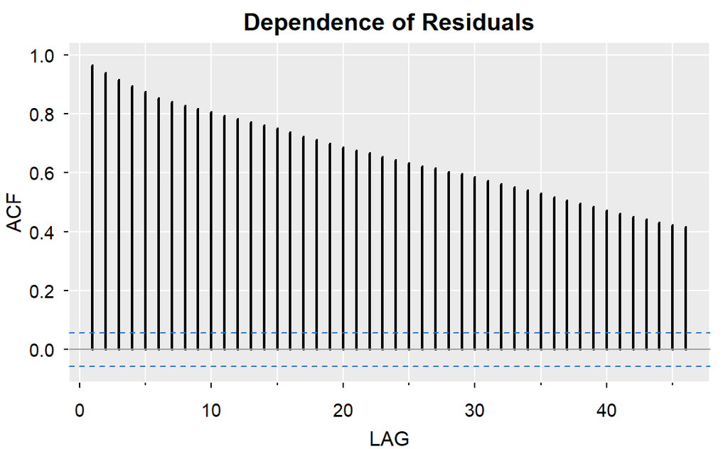

```r
fit1.residuals<- fit1 %>% resid()
tsplot(fit1.residuals,col=astsa.col(4, .8),gg=TRUE,lwd=1,main = "Residuals",ylab = "",xlab = "Series")
acf1(fit1.residuals,main = "Dependence of Residuals",gg=TRUE,lwd=2)
```

(3). From the previous ACF plot, we understand that the residuals are not stationary series. After difference,from the below graph, the series becomes stable. From ACF and PACF plots below, we notice the the structure might be ARIMA(0,1,1) because ACF cuts off and PACF tails off. Also, there seems to be seasonality for lag 6, so we should also consider SARIMA(0,1,1,0,0,1,6) because seasonal ACF cuts off and PACF tails off.

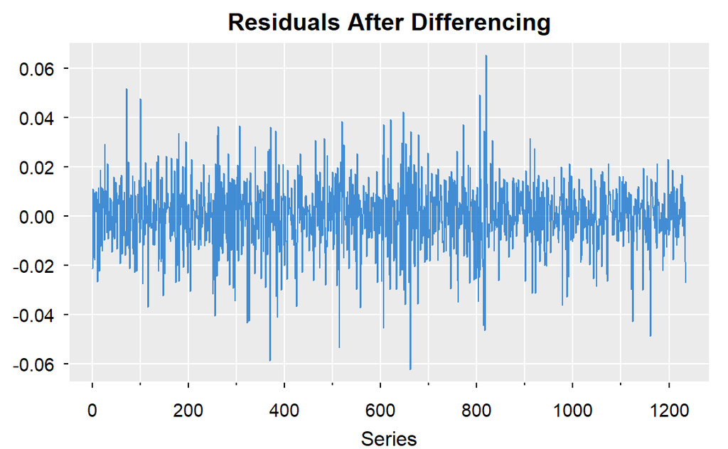

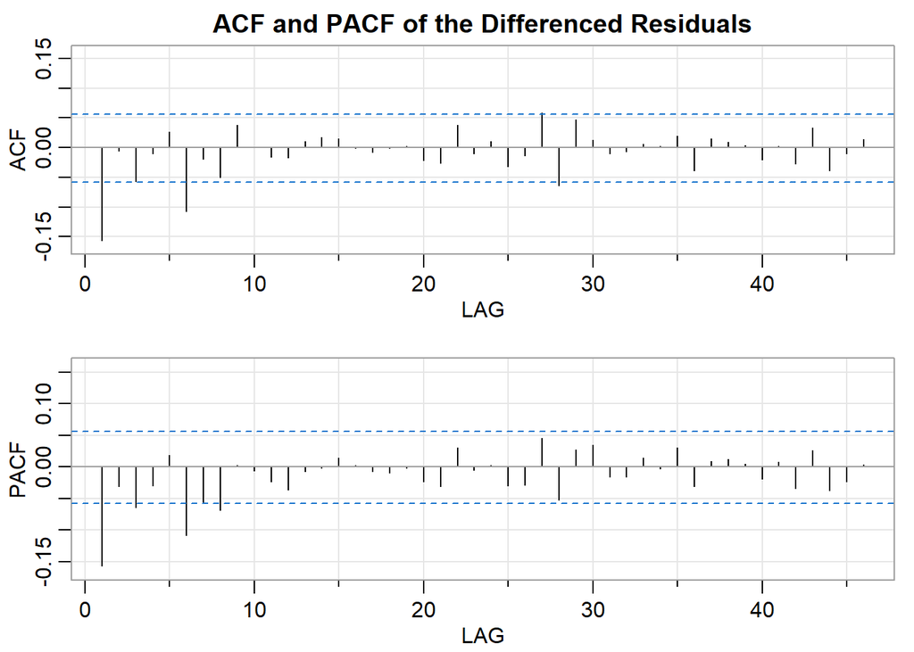

```
##       [,1]  [,2]  [,3]  [,4] [,5]  [,6]  [,7]  [,8] [,9] [,10] [,11] [,12]
## ACF  -0.16 -0.01 -0.06 -0.01 0.03 -0.11 -0.02 -0.05 0.04  0.00 -0.02 -0.02
## PACF -0.16 -0.03 -0.06 -0.03 0.02 -0.11 -0.06 -0.07 0.00 -0.01 -0.02 -0.04
##      [,13] [,14] [,15] [,16] [,17] [,18] [,19] [,20] [,21] [,22] [,23] [,24]
## ACF   0.01  0.02  0.02     0 -0.01  0.00     0 -0.02 -0.03  0.04 -0.01  0.01
## PACF -0.01  0.00  0.01     0 -0.01 -0.01     0 -0.02 -0.03  0.03  0.00  0.00
##      [,25] [,26] [,27] [,28] [,29] [,30] [,31] [,32] [,33] [,34] [,35] [,36]
## ACF  -0.03 -0.01  0.06 -0.06  0.05  0.01 -0.01 -0.01  0.01     0  0.02 -0.04
## PACF -0.03 -0.03  0.05 -0.05  0.03  0.03 -0.02 -0.02  0.01     0  0.03 -0.03
##      [,37] [,38] [,39] [,40] [,41] [,42] [,43] [,44] [,45] [,46]
## ACF   0.02  0.01     0 -0.02  0.00 -0.03  0.03 -0.04 -0.01  0.01
## PACF  0.01  0.01     0 -0.02  0.01 -0.03  0.03 -0.04 -0.02  0.00
```

```r
fit1.residuals.diff<- fit1.residuals %>% diff()
tsplot(fit1.residuals.diff,col=astsa.col(4, .8),gg=TRUE,lwd=1,main = "Residuals After Differencing",ylab = "",xlab = "Series")
```

(4). For ARIMA(0,1,1), from below, the t-table suggests that the MA part is significant. However, the box statistics indicates that the serial correlation has not been solved.

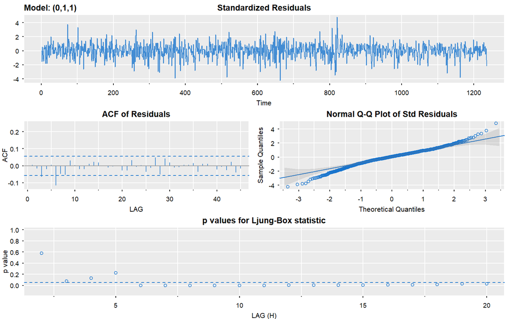

```r
resid1<- sarima(fit1.residuals,0,1,1,no.constant = T,details = T,gg=TRUE, col=astsa.col(4, .8))
```

```r
resid1$ttable
```

```
##     Estimate     SE t.value p.value
## ma1  -0.1682 0.0292 -5.7547       0
```

(5). For SARIMA(0,1,1,0,0,1,6), the below t-table suggests the SMA part is significant as well. In addition, serial correlation seems to improve. We first try to employ this residual structure to run a new regression with autocorrelated error model.

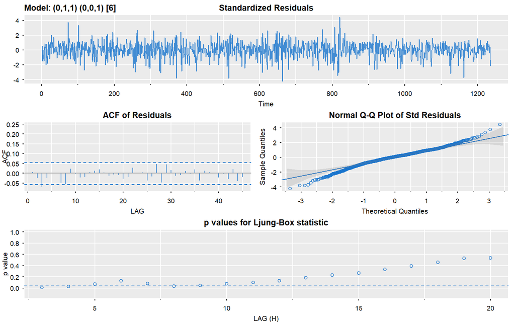

```r
resid2<- sarima(fit1.residuals,0,1,1,0,0,1,6,no.constant = T,details = T,gg=TRUE, col=astsa.col(4, .8))
```

```r
resid2$ttable
```

```
##      Estimate     SE t.value p.value
## ma1   -0.1755 0.0296 -5.9280       0
## sma1  -0.1216 0.0289 -4.2002       0
```

(6). From the box statistics below, the serial correltion problems in residuals are solved. However, one serious issue appears, which is the time predictor variable becomes insignificant. We suspect that since time variable might be highly correlated with the residuals and thus when residuals are restructured, it becomes insignificant. Therefore, we try to exclude the variable and rebuild the model.

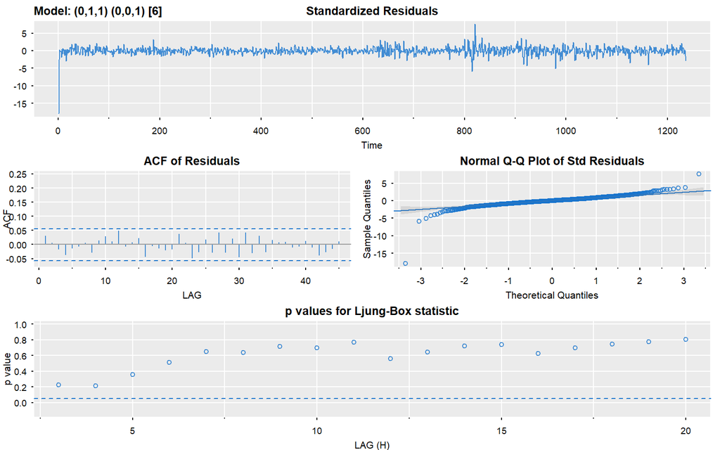

```r
fit2<- sarima(data1$gold_log,0,1,1,0,0,1,6
              ,xreg = cbind(data1$vol_log,I((data1$vol_log)^2),data1$time),details = T,gg=TRUE, col=astsa.col(4, .8))
```

```r
fit2$ttable
```

```
##       Estimate     SE t.value p.value
## ma1     0.0380 0.0287  1.3214  0.1866
## sma1   -0.0739 0.0276 -2.6794  0.0075
## xreg1   0.0995 0.0369  2.6995  0.0070
## xreg2  -0.0158 0.0065 -2.4196  0.0157
## xreg3   0.0785 0.0570  1.3788  0.1682
```

(7). We rebuild a model without the time variable and inspect the residuals again. From below, after difference, we recognize similar residual structure. That is, SARIMA(0,1,1,0,0,1,6).

```r
fit3<- lm(gold_log~vol_log+I(vol_log^2),data = data1)
fit3.residuals<- fit3 %>% resid()
fit3.residuals.diff<- fit3.residuals %>% diff()
```

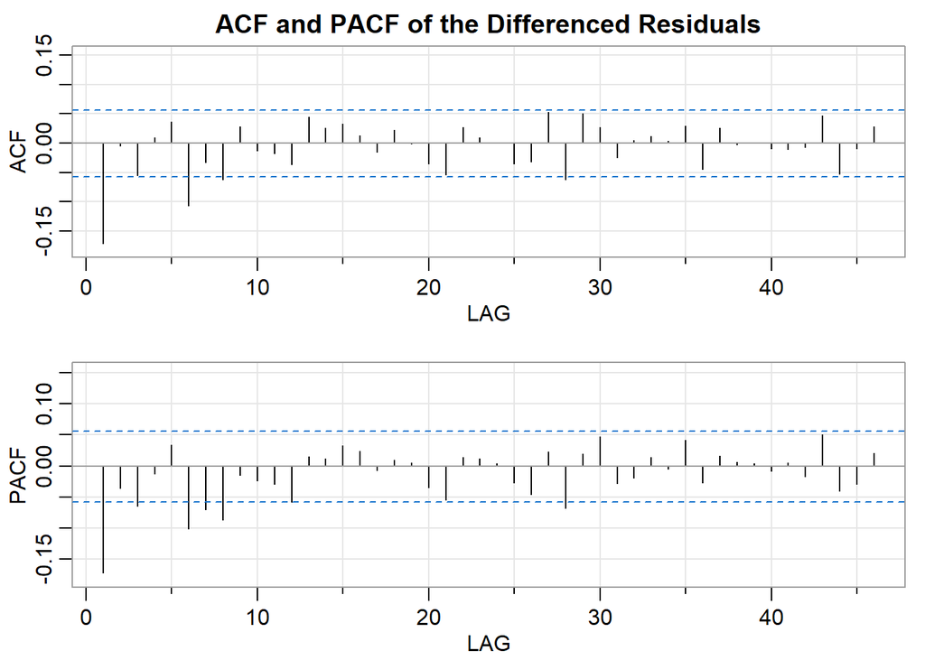

```
##       [,1]  [,2]  [,3]  [,4] [,5]  [,6]  [,7]  [,8]  [,9] [,10] [,11] [,12]
## ACF  -0.17 -0.01 -0.06  0.01 0.04 -0.11 -0.03 -0.06  0.03 -0.01 -0.02 -0.04
## PACF -0.17 -0.04 -0.06 -0.01 0.03 -0.10 -0.07 -0.09 -0.01 -0.02 -0.03 -0.06
##      [,13] [,14] [,15] [,16] [,17] [,18] [,19] [,20] [,21] [,22] [,23] [,24]
## ACF   0.04  0.03  0.03  0.01 -0.01  0.02  0.00 -0.04 -0.05  0.03  0.01     0
## PACF  0.02  0.01  0.03  0.02 -0.01  0.01  0.01 -0.03 -0.05  0.01  0.01     0
##      [,25] [,26] [,27] [,28] [,29] [,30] [,31] [,32] [,33] [,34] [,35] [,36]
## ACF  -0.03 -0.03  0.05 -0.06  0.05  0.03 -0.03  0.00  0.01     0  0.03 -0.04
## PACF -0.03 -0.05  0.02 -0.07  0.02  0.05 -0.03 -0.02  0.01     0  0.04 -0.03
##      [,37] [,38] [,39] [,40] [,41] [,42] [,43] [,44] [,45] [,46]
## ACF   0.03  0.00     0 -0.01 -0.01 -0.01  0.05 -0.05 -0.01  0.03
## PACF  0.02  0.01     0 -0.01  0.00 -0.02  0.05 -0.04 -0.03  0.02
```

(8). From t-table below, all the parts are significant but the serial correlation in residuals seems to be unsolved. Still, we try to employ this new structure to run a regression with auto-correlated error model again.

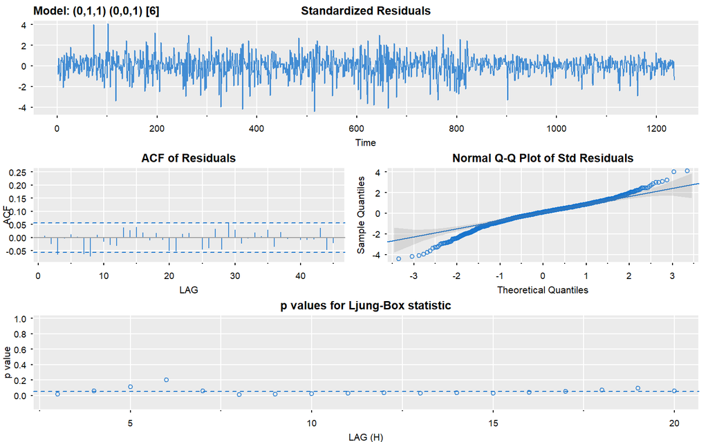

```r
resid3<- sarima(fit3.residuals,0,1,1,0,0,1,6,no.constant = T,details = T,gg=TRUE, col=astsa.col(4, .8))
```

```r
resid3$ttable
```

```
##      Estimate     SE t.value p.value
## ma1   -0.1924 0.0294 -6.5547       0
## sma1  -0.1245 0.0291 -4.2825       0
```

(9). This time the predictor variables all remain significant. However, We discover that the MA parts of the residuals become insignificant. We then exclude it and see how the model responds.

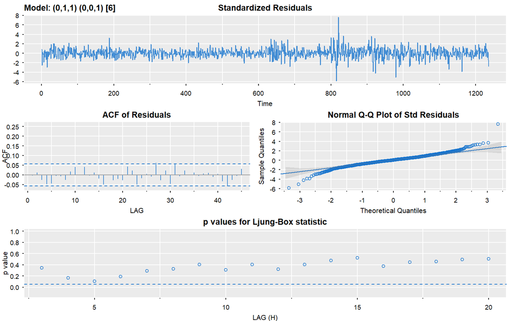

```r
fit4<- sarima(data1$gold_log,0,1,1,0,0,1,6
              ,xreg = cbind(data1$vol_log,I((data1$vol_log)^2)),details = T,gg=TRUE, col=astsa.col(4, .8))
```

```r
fit4$ttable
```

```
##       Estimate     SE t.value p.value
## ma1     0.0397 0.0287  1.3861  0.1660
## sma1   -0.0720 0.0275 -2.6167  0.0090
## xreg1   0.0990 0.0369  2.6858  0.0073
## xreg2  -0.0157 0.0065 -2.4083  0.0162
```

(10). After eliminating the MA parts, the remaining seasonal part is still significant. More importantly, we see that the residuals are mostly uncorrelated with only one point being significant. Also, the residual approximately normally distributed. Therefore, we select this model with variable log(volatility), log(volatility)^2 with auto-correlated errors SARIMA(0,1,0,0,0,1,6).

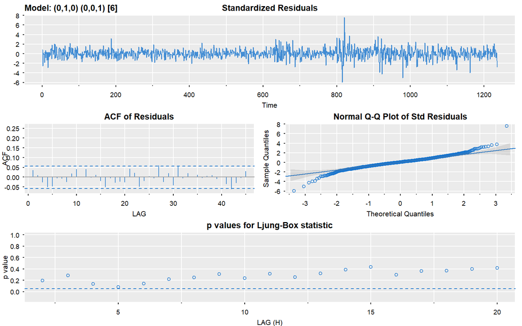

```r
fit5<- sarima(data1$gold_log,0,1,0,0,0,1,6
              ,xreg = cbind(data1$vol_log,I((data1$vol_log)^2)),details = T,gg=TRUE, col=astsa.col(4, .8))
```

```r
fit5$ttable
```

```
##       Estimate     SE t.value p.value
## sma1   -0.0738 0.0275 -2.6842  0.0074
## xreg1   0.1065 0.0366  2.9090  0.0037
## xreg2  -0.0169 0.0065 -2.6072  0.0092
```

## Time Series Model - Seasonal ARIMA

```r
data2<- Gold %>% as_tibble() %>% rename(gold=GOLDAMGBD228NLBM)
data2<- data2 %>% filter(gold != ".") %>% mutate_at("gold",as.numeric)
data2<- data2 %>% mutate(gold_log=log(gold))
data2<- data2 %>% separate(DATE, into=c("Year","Month","Date"),sep="-")
time.2016<- seq(from=2016, to=2017,by=1/251)[226:251]
time.2017<- seq(from=2017,to=2018,by=1/251)[1:251]
time.2018<- seq(from=2018,to=2019,by=1/253)[1:253]
time.2019<- seq(from=2019,to=2020,by=1/252)[1:252]
time.2020<- seq(from=2020,to=2021,by=1/253)[1:253]
time.2021<- seq(from=2021,to=2022,by=1/227)[1:227]
time.stamp<- c(time.2016,time.2017,time.2018,time.2019,time.2020,time.2021)
data2<- data2 %>% mutate(time=time.stamp)
```

(1). From previous preliminary data analysis, we already know that the series is not stationary after the log-transformation. Thus, we first take difference of the data and the series becomes stationary.

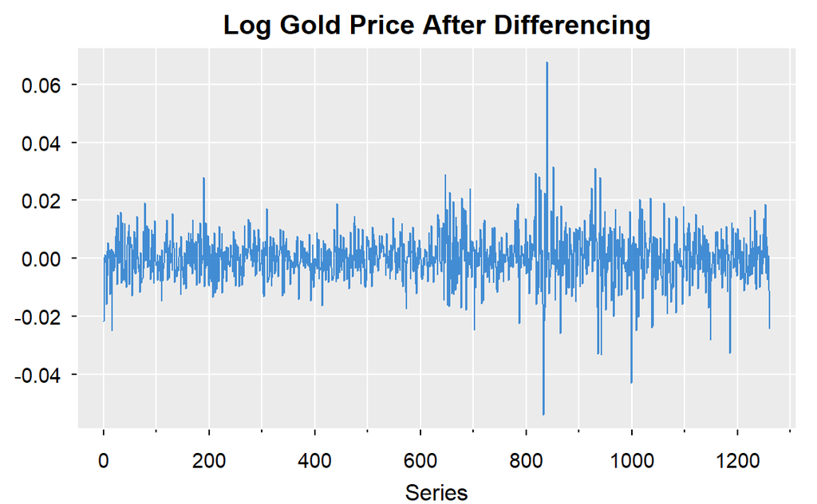

```r
diff.log.gold<- diff(data2$gold_log)
tsplot(diff.log.gold,main = "Log Gold Price After Differencing",gg=T,ylab = "",xlab = "Series",col = astsa.col(4, .8))
```

2. From the below graph, we observe non-seasonal part reveals ARIMA(1,1,0) or ARIMA(0,1,1). Both will be acceptable and the results will be close. Seasonal parts are both tailing off in lag 6. Thus, seasonal models are warranted. We compare SARIMA(1,1,0)(1,0,0)(6), SARIMA(0,1,1)(1,0,0,6), and SARIMA(0,1,1)(1,0,1)(6)

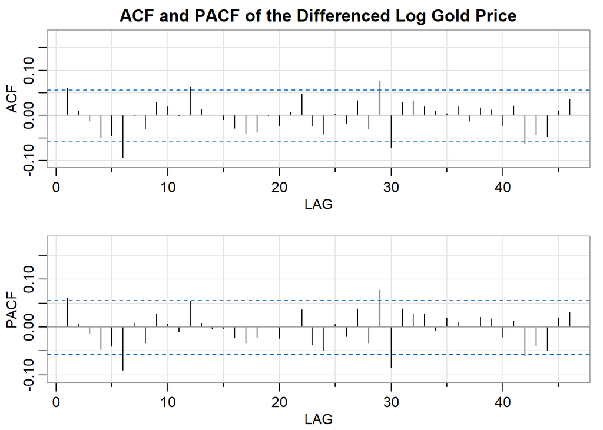

```
##      [,1] [,2]  [,3]  [,4]  [,5]  [,6] [,7]  [,8] [,9] [,10] [,11] [,12] [,13]
## ACF  0.06 0.01 -0.01 -0.05 -0.05 -0.09 0.00 -0.03 0.03  0.02  0.00  0.06  0.01
## PACF 0.06 0.01 -0.01 -0.05 -0.04 -0.09 0.01 -0.03 0.03  0.01 -0.01  0.05  0.01
##      [,14] [,15] [,16] [,17] [,18] [,19] [,20] [,21] [,22] [,23] [,24] [,25]
## ACF      0 -0.01 -0.03 -0.04 -0.04     0 -0.02  0.01  0.05 -0.02 -0.04  0.00
## PACF     0  0.00 -0.02 -0.03 -0.02     0 -0.02  0.00  0.04 -0.04 -0.05  0.01
##      [,26] [,27] [,28] [,29] [,30] [,31] [,32] [,33] [,34] [,35] [,36] [,37]
## ACF  -0.02  0.03 -0.03  0.08 -0.07  0.03  0.03  0.02  0.01  0.00  0.02 -0.01
## PACF -0.02  0.04 -0.03  0.08 -0.08  0.04  0.03  0.03 -0.01  0.02  0.01  0.00
##      [,38] [,39] [,40] [,41] [,42] [,43] [,44] [,45] [,46]
## ACF   0.02  0.01 -0.02  0.02 -0.06 -0.04 -0.05  0.01  0.04
## PACF  0.02  0.02 -0.02  0.01 -0.06 -0.04 -0.05  0.02  0.03
```

```r
acf2(diff.log.gold,main = "ACF and PACF of the Differenced Log Gold Price")
```

3. From the below t-tables and residual analysis, we understand that all the estimated parts are significant and thus all the models deserve some considerations. Also, the box statistics are never significant in all three models, and residuals seem to break away from normal distribution only at tail.

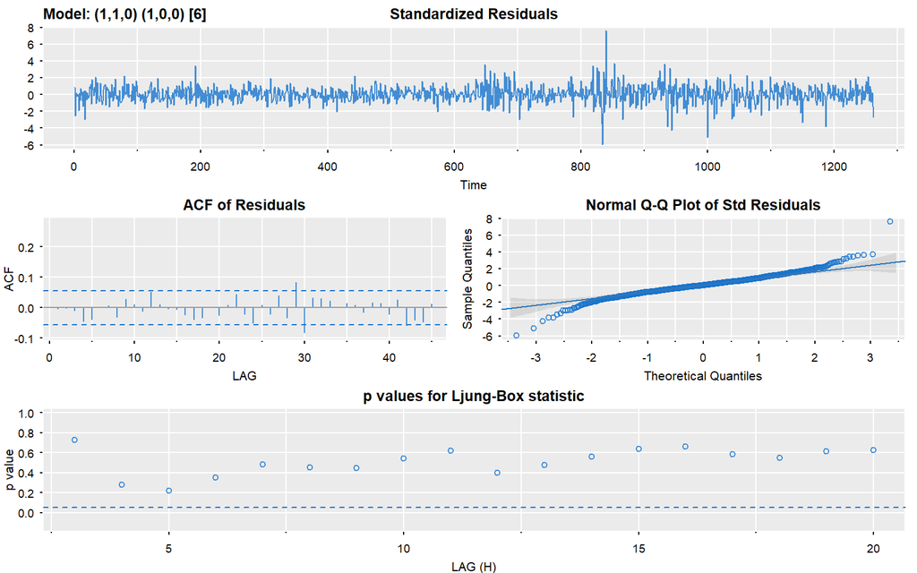

```r
ts1<- sarima(data2$gold_log,1,1,0,1,0,0,6,no.constant = T,details = T,gg=TRUE, col=astsa.col(4, .8))
```

```r
ts1$ttable
```

```
##      Estimate     SE t.value p.value
## ar1    0.0594 0.0283  2.1005  0.0359
## sar1  -0.0918 0.0282 -3.2521  0.0012
```

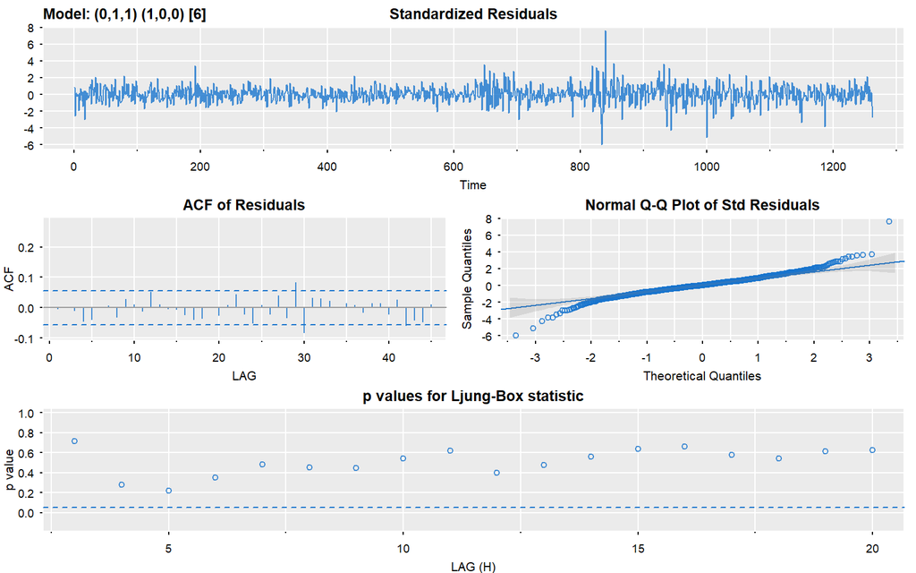

```r
ts2<- sarima(data2$gold_log,0,1,1,1,0,0,6,no.constant = T,details = T,gg=TRUE, col=astsa.col(4, .8))
```

```r
ts2$ttable
```

```
##      Estimate     SE t.value p.value
## ma1    0.0591 0.0281  2.0996  0.0360
## sar1  -0.0921 0.0282 -3.2626  0.0011
```

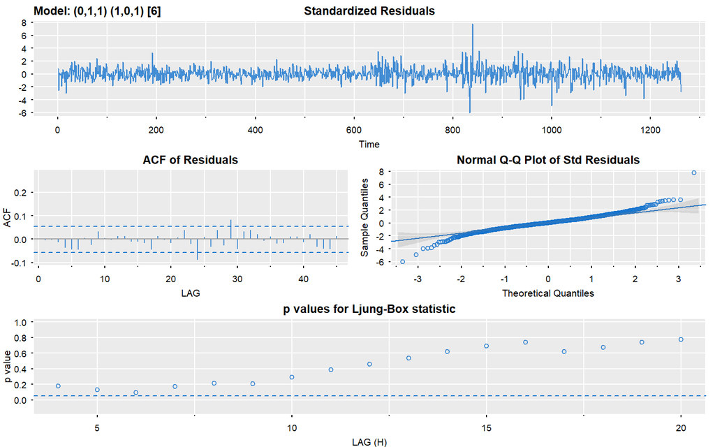

```r
ts3<- sarima(data2$gold_log,0,1,1,1,0,1,6,no.constant = T,details = T,gg=TRUE, col=astsa.col(4, .8))
```

```r
ts3$ttable
```

```
##      Estimate     SE  t.value p.value
## ma1    0.0650 0.0282   2.2995  0.0216
## sar1  -0.9379 0.0501 -18.7337  0.0000
## sma1   0.8968 0.0649  13.8205  0.0000
```

(4). From AIC and BIC, all the models are close, AIC suggests the third while BIC suggests the first. We decide to propose the first model for its simplicity.

```
## [1] "AIC : -6.7222 -6.7222 -6.726"
```

```
## [1] "BIC -6.70999 -6.70997 -6.70974"
```

(5). With the established model SARIMA(1,1,0,1,0,0,6), we provide 5-step ahead forecast and their corresponding SE. Note that we forecast in log-terms.

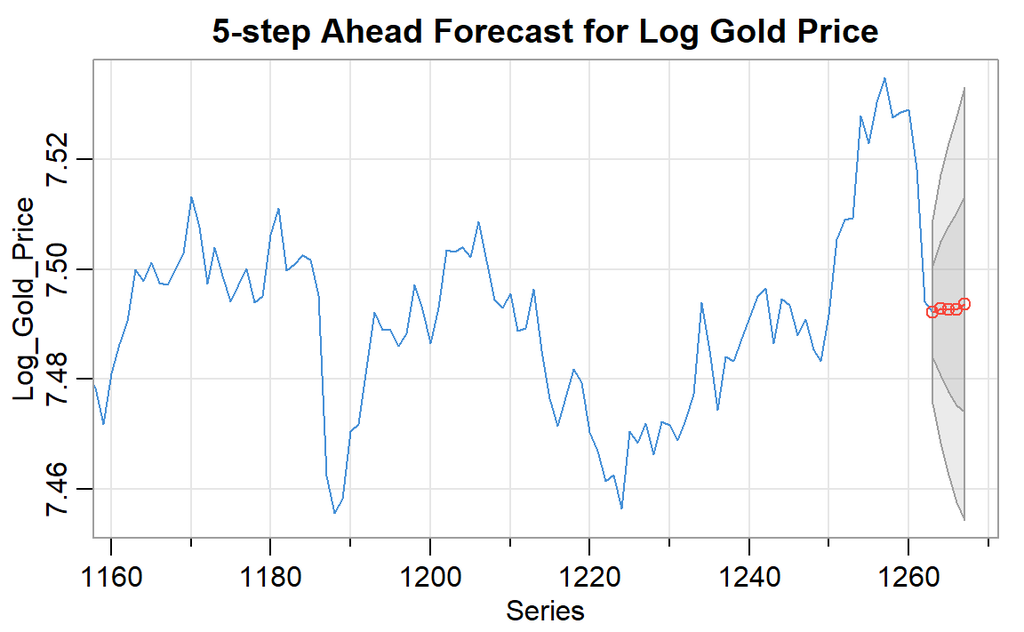

```
## $pred
## Time Series:
## Start = 1263
## End = 1267
## Frequency = 1
## [1] 7.492236 7.492833 7.492726 7.492682 7.493688
##
## $se
## Time Series:
## Start = 1263
## End = 1267
## Frequency = 1
## [1] 0.008375478 0.012201556 0.015104056 0.017533349 0.019664842
```

```r
Log_Gold_Price<- data2$gold_log
sarima.for(Log_Gold_Price,1,1,0,1,0,0,6,n.ahead = 5
           ,no.constant = T,plot.all = F,xlab="Series",col=astsa.col(4, .8),lty=1,pch="",main="5-step Ahead Forecast for Log Gold Price")
```

## Comparison- Prediction RMSE

```r
training_gold_log<-data1$gold_log[1:1231]
training_vol_log<- data1$vol_log[1:1231]
training_vol_log_square<- training_gold_log^2

testing_vol_log<- data1$vol_log[1232:1236]
testing_gold<- data1$gold[1232:1236]

GLS<- sarima(data1$gold_log,0,1,0,0,0,1,6
              ,xreg = cbind(data1$vol_log,I((data1$vol_log)^2)),details = F,gg=TRUE, col=astsa.col(4, .8))

Time_series<- sarima(data1$gold_log,1,1,0,1,0,0,6,no.constant = T,details = F,gg=TRUE, col=astsa.col(4, .8))



GLS_forecast<- sarima.for(training_gold_log,0,1,0,0,0,1,6,n.ahead = 5
              ,xreg = cbind(training_vol_log,I((training_vol_log)^2)),newxreg = cbind(testing_vol_log,I((testing_vol_log)^2)),plot = F)


Time_series_forcast<- sarima.for(training_gold_log,1,1,0,1,0,0,6,n.ahead = 5
           ,no.constant = T,plot = F)

GLS_prediction<- exp(GLS_forecast$pred)
Time_series_prediction<- exp(Time_series_forcast$pred)

# rmse
rmse_GLS<- sqrt(mean((GLS_prediction-testing_gold)^2))
rmse_time<- sqrt(mean((Time_series_prediction-testing_gold)^2))

results<- data.frame(series=1:5,True_value=testing_gold,GLS=GLS_prediction,time=Time_series_prediction)

results<-as_tibble(results)

colnames(results)<-c("Series","True Value","GLS","Time Series")
results
```

| Series | True Value | GLS | Time Series |
| --- | --- | --- | --- |
| 1 | 1858.45 | 1871.859 | 1872.332 |
| 2 | 1860.50 | 1871.205 | 1872.321 |
| 3 | 1861.40 | 1868.365 | 1869.782 |
| 4 | 1841.10 | 1869.894 | 1870.462 |
| 5 | 1797.30 | 1869.095 | 1869.449 |

```r
results_prediction<- data.frame(GLS=rmse_GLS,Time_Series=rmse_time)
rownames(results_prediction)<-"RMSE"
colnames(results_prediction)<- c("GLS","Time Series")
results_prediction
```

|  | GLS | Time Series |
| --- | --- | --- |
| RMSE | 35.57108 | 35.97294 |

```r
# 1.8%
```

# Results

# Discussion

1. Though volatility index is closely related to gold fixing price, it is somehow an indirect connection, because it traces a pool of gold related stocks which are themselves complex data. It might be better if we can find an more direct pool of data.
2. By building the regression model, we are only estimating the association. The underlying connection between volatility and fixing price can be complicated. To further establish other association or explain more variation, we should incorporate more fundamental macroeconomic data. For various related economic data, we may consider to use PCR to avoid multi-collinearity issues.
3. In predicting the gold fixing price, we use a time series model. However, we do not do any cross-validation to fine tune the parameters. Thus, we do not know how effective this model is.